# Camera trap survey designs for Zhanaidar & Bek Tosot community conservancies

Oliver Wearn

September 2025

```r
# Load some packages
library(sf)
library(terra)
library(secrdesign)
library(elevatr)
library(plyr)
library(leaflet)
library(kableExtra)
library(reshape)
library(ggplot2)
library(patchwork)

# Define project for study area
study.crs <- "EPSG:32643" # 43 N
```

## 1. Introduction

In this notebook we explore camera trap survey designs for two community conservancies in the Pamir Alay: Zhanaidar and Bek Tosot. The objectives for the surveys are two-fold:

1. To produce a first estimate of snow leopard density (ideally with a low coefficient of variation)
2. To produce occupancy estimates for key wildlife species, with a particular focus on ungulates

Given that the survey design requirements for estimating density are stricter than those for estimating occupancy, we will here focus on designing the survey from the perspective of estimating density. The data will still be suitable for occupancy modelling.

We will assume that 40 and 60 camera traps are available for the Zhanaidar and Bek Tosot surveys, respectively. The plan is to combine both datasets into a single analysis. Sample sizes, especially for snow leopard density estimation, are unlikely to be sufficient for each conservancy in isolation.

We will also assume that camera traps can remain in place for a minimum of 2 months.

## 2. Load and prep data

First we load some data, including the conservancy boundaries and a coarse-scale density surface for Kyrgyzstan (from national-scale PAWS modelling, produced at 2 km resolution).

```r
# Set working directory
wd <- "/Users/ollie/Dropbox/SLT/"
setwd(wd)
knitr::opts_knit$set(root.dir=wd)

# Read in protected area shapefile
conservancy <- st_transform(st_read("GIS/Kyrgyzstan/UNDP Pamir-Alay/Pamir_Alai_Shape_Files/Ilbirs.shp", quiet=T), crs=study.crs) # already in UTM 43N so no need to transform

# Density surface for Kyrgyzstan
density.surface <- rast("PAWS/Kyrgyzstan/56_KyrgyzCountry (2025-04-14)/output/results/no_outlier_withpanthera/allkyrg_predicted_densities_no_outlier_noslope.tif") # no CRS
crs(density.surface) <- study.crs

# Elevation data
elev <- get_elev_raster(st_buffer(conservancy, 5000), z=9, clip="bbox") # z=9 gives 118 m resolution data

# Define the resources for the two surveys
n.cameras <- c(40, 60)
## Survey period for each camera trap of at least 60 days
survey.days <- 60
```

## 3. Define the survey area

### 3.1. Minimum camera spacing

We have to make some decisions in order to run the genetic algorithm. First, we have to decide what the *minimum* spacing between our cameras will be.

Published recommendations for spacing are that it should be at least half the sigma estimate from SECR modelling, and perhaps more towards 2/3<sup>rds</sup> the sigma estimate (Durbach *et al.* 2021). Sigma was 5,435 m (95% CI: 4,924 - 6,000 m) from the national-scale PAWS modelling. This suggests that the minimum spacing should be at least 2.7 km, and perhaps more towards 3.6 km.

*However*, in discussion with Ian Durbach, using 3-4 km carries a greater risk of obtaining too few spatial recaptures. This means that the survey might fail entirely. In practice, using 2 km spacing reduces the risk of survey failure, at the slight cost of a less precise density estimate.

```r
# Define minimum spacing
minimum.spacing <- 2000

# Make grid of potential camera locations across the two conservancies
camera.grid <- st_make_grid(conservancy, what="corners", cellsize=rep(minimum.spacing, 2))

# Select the cameras inside the conservancy boundaries
camera.grid <- camera.grid[conservancy]
```

### 3.2. Altitudinal limits

Next, we have to decide the altitudinal limits of our survey. Following national-scale PAWS modelling, we will use 2,000 m as the lower limit. As the upper limit we will use 4,500 m, since accessibility of areas will be difficult above this. Let’s see what those limits looks like on a map.

```r
# Define altitudinal limits
altitudinal.limits <- c(2000, 4500)

# Subset by elevation
camera.elevation <- extract(elev, st_as_sf(camera.grid))
camera.grid.subs <- camera.grid[camera.elevation > altitudinal.limits[1] & camera.elevation < altitudinal.limits[2]]

# Create a raster of the elevation limits
elev.limits <- mask(elev, conservancy)
elev.limits <- app(rast(elev.limits), function(x) {
  x[x <= altitudinal.limits[1] | x >= altitudinal.limits[2]] <- 0
  x[x > altitudinal.limits[1] & x < altitudinal.limits[2]] <- 1
  x
})

# Plot it
leaflet() %>%
  addProviderTiles("Esri.WorldImagery") %>%
  addPolylines(data=st_transform(conservancy, "EPSG:4326"), color="black", opacity=0.8, weight=2) %>%
  addRasterImage(elev.limits, colors=c("red", "grey"), opacity=0.5) %>%
  addLegend(labels=c("Excluded areas", "Included areas"), colors=c("red", "grey"))
```

[interactive chart not shown]

### 3.3. Ruggedness limits

There is a large and flat grassland expanse in the middle of Zhanaidar, which we can exclude from sampling. In discussions with the team, we don’t expect this area to have any key species of interest. To cut it out from the survey design, we can use a threshold ruggedness value.

```r
# Reduce the resolution of the elevation layer before calculating ruggedness
elev.low <- aggregate(elev, fact=4)

# Calculate ruggedness from elevation
rugged.low <- terrain(elev.low, v="TRI")

# Mask it by the park
rugged.low <- mask(rugged.low, conservancy)

# Define lower ruggedness limit
ruggedness.limit <- 0.06

# Create a raster of the low ruggedness areas
rugged.limit <- app(rast(rugged.low), function(x) {
  x[x > ruggedness.limit] <- 0
  x[x < ruggedness.limit & x!=0] <- 1
  x
})

# Only keep the two largest patches of low ruggedness as the areas for removal
rugged.patches <- patches(rugged.limit, zeroAsNA=T)
rugged.patches <- zonal(cellSize(rugged.patches, unit="km"), rugged.patches, sum, as.raster=TRUE)
rugged.patches.areas <- sort(unique(values(rugged.patches)), decreasing=T)
rugged.patches <- classify(rugged.patches, rcl=matrix(c(rugged.patches.areas[1:3], rep(1, 3)), ncol=2), others=NA)

# Fill the holes in the two flat areas
rugged.patches.vect <- as.polygons(rugged.patches)
rugged.patches.vect <- fillHoles(rugged.patches.vect)
rugged.limit <- rasterize(rugged.patches.vect, rugged.patches)

# Plot it
leaflet() %>%
  addProviderTiles("Esri.WorldImagery") %>%
  addPolylines(data=st_transform(conservancy, "EPSG:4326"), color="black", opacity=0.8, weight=2) %>%
  addRasterImage(rugged.limit, colors=c("red", "grey"), opacity=0.7) %>%
  addLegend(labels=c("Excluded areas", "Included areas"), colors=c("red", "grey"))
```

[interactive chart not shown]

### 3.4. Map the survey area

Given the altitudinal and ruggedness limits, we now map the final survey area.

```r
# Overlay the altitudinal and ruggedness limits to get the final survey area
rugged.limit <- classify(rugged.limit, rcl=matrix(c(1, NA, 0, 1), ncol=2))
rugged.limit <- resample(rugged.limit, elev.limits, method="near")
survey.area <- elev.limits + rugged.limit

# Plot it
leaflet() %>%
  addProviderTiles("Esri.WorldImagery") %>%
  addPolylines(data=st_transform(conservancy, "EPSG:4326"), color="black", opacity=0.8, weight=2) %>%
  addRasterImage(survey.area, colors=c("red", "grey"), opacity=0.6) %>%
  addLegend(labels=c("Excluded areas", "Included areas"), colors=c("red", "grey"))
```

[interactive chart not shown]

Get the areas of the two survey areas (in km<sup>2</sup>).

```r
# Extract just the area of overlap between the altitudinal and ruggedness limits
survey.area <- classify(survey.area, rcl=matrix(c(2, 1), ncol=2), others=NA)

# Get rid of small pixels caused by minor alignment issues
survey.area.patches <- patches(survey.area, zeroAsNA=T)
survey.area.patches <- zonal(cellSize(survey.area.patches, unit="km"), survey.area.patches, sum, as.raster=TRUE)
survey.area.patches.areas <- sort(unique(values(survey.area.patches)), decreasing=T)
survey.area.patches <- classify(survey.area.patches, rcl=matrix(c(survey.area.patches.areas[1:3], rep(1, 3)), ncol=2), others=NA)

# Split up the vector layer into the two conservancies
survey.area.vect <- st_cast(st_as_sf(as.polygons(survey.area.patches)), "POLYGON")
survey.area.vect$conservancy <- c("Zhanaidar", "Zhanaidar", "Bek Tosot")

# Calculate the areas
as.numeric(sum(st_area(survey.area.vect)[1:2]) / 1000^2) # 750 km2
```

```
## [1] 750.2327
```

```r
as.numeric(sum(st_area(survey.area.vect)[3]) / 1000^2) # 2134 km2
```

```
## [1] 2133.836
```

## 4. Create survey designs

Next we create survey designs for consideration.

We use the *GAoptim* function in the ‘secrdesign’ package, which uses a genetic algorithm to find a survey design which should efficiently detect a good sample of snow leopard individuals, including recaptures of those individuals (Durbach *et al.* 2021).

We will assume that if a survey design is sufficient for density estimation (Objective 1) it will also be sufficient for occupancy estimation (Objective 2), which is typically less demanding in terms of sample sizes.

### 4.1. Expected values of SECR parameters

Before running the genetic algorithm, we need to choose some expected values for the main SECR parameters, which are:

- *density*
- *lambda0* - the encounter rate per camera trap per day
- *sigma* - the spatial scale of movement for the hazard half-normal distribution

For the detection parameters - *lambda0* and *sigma* - we’ll use approximate values taken from the nationwide PAWS analysis for Kyrgyzstan. Specifically, we’ll use a *lambda0* of 0.010 (averaged across Reconyx and other camera trap brands) and a *sigma* of 5,400 (approximately similar to the actual estimate of 5,435 m).

```r
expected.lambda0 <- 0.01
expected.sigma <- 5400
```

For density, we’ll take the average density from the nationwide density surface.

```r
density.survey <- mask(density.surface, survey.area.vect)
expected.density <- as.numeric(global(density.survey, "mean", na.rm=T))
```

The mean expected density across the survey area is 0.23 snow leopards per 100 km<sup>2</sup>.

### 4.2. Generate survey designs

Issues during field work are common - for example loss or theft of cameras, or camera malfunctions - so total survey effort is typically less than planned. To account for that, we’ll assume there’s a 10% loss of effort, in terms of number of camera locationss and survey days. We do that by randomly deleting 10% of camera locations from the proposed design.

Note that the loss factor on camera traps is only used for assessing the suitability of the proposed survey design. It is removed to obtain the final survey design with the full number of available camera traps.

We’re now ready to generate a survey design using the genetic algorithm. We will first generate a survey design for both conservancies as part of a single study.

#### 4.2.1. Both conservancies together

```r
# Define the loss factor
loss.factor <- 0.1

# Mask the camera grid by the final survey area
camera.grid.survey <- camera.grid.subs[survey.area.vect]

# Turn the potential camera locations into a secr 'traps' object
potential.traps.df <- data.frame(x=st_coordinates(camera.grid.survey)[,1], y=st_coordinates(camera.grid.survey)[,2])
potential.traps <- read.traps(data=potential.traps.df, detector="count")

# Create a 'mask' object, which is needed for numerical calculations
# This will have 1.5 km spacing, which is often used for snow leopard density modelling (because it provides sufficient resolution for modelling of activity centres without overburdening the numerical calculations with too many points)
# A buffer of 3 * sigma will be used (following Durbach et al. 2021)
mask.outline <- st_union(st_buffer(camera.grid.survey, dist=3 * expected.sigma))
secr.mask <- st_make_grid(mask.outline, what="corners", cellsize=c(1500, 1500))
secr.mask <- secr.mask[mask.outline]
mask.df <- data.frame(x=st_coordinates(secr.mask)[,1], y=st_coordinates(secr.mask)[,2])
design.mask <- read.mask(data=mask.df)

# Define SECR parameter list
secr.params <- list(lambda0=expected.lambda0 * survey.days * (1 - loss.factor), sigma=expected.sigma)

# Create design which maximises the number of individuals and recaptures (minimum of either)
proposed.design.both <- GAoptim(mask=design.mask,
               alltraps=potential.traps,
               ntraps=sum(n.cameras),
               detectpar=secr.params,
               D=expected.density / 10000, # convert to density per ha
               criterion=4,
               seed=999,
               noccasions=1, detectfn="HHN",
               ngen=200, verbose=F)

# Randomly remove 10% of camera traps
proposed.design.both.loss10 <- proposed.design.both
proposed.design.both.loss10$optimaltraps <- proposed.design.both$optimaltraps[sample(1:nrow(proposed.design.both$optimaltraps), size=nrow(proposed.design.both$optimaltraps) * (1 - loss.factor), replace=F), ]
```

Plot the proposed design.

```r
# Create a spatial layer of the proposed camera locations
cameras.both.sf <- st_as_sf(proposed.design.both$optimaltraps, coords=c("x", "y"), crs=study.crs)

# Plot it
leaflet() %>%
  addProviderTiles("Esri.WorldImagery") %>%
  addPolylines(data=st_transform(conservancy, "EPSG:4326"), color="black", opacity=0.8, weight=2) %>%
  addCircleMarkers(data=st_transform(cameras.both.sf, "EPSG:4326"), stroke=T, weight=1.2, fillOpacity = 0.8, color="black", fillColor="orange", radius=7, popup=cameras.both.sf$camera_ID)
```

[interactive chart not shown]

In this design, there are 63 cameras in Bek Tosot and 37 cameras in Zhanaidar.

#### 4.2.2. Zhanaidar conservancy alone

Next we generate a design using the n = 40 cameras available for Zhanaidar.

```r
# Mask the camera grid by Zhanaidar
camera.grid.zh <- camera.grid.survey[conservancy[conservancy$Name=="Zhanaidar", ]]

# Turn the potential camera locations into a secr traps object and then make a mask
potential.traps.zh.df <- data.frame(x=st_coordinates(camera.grid.zh)[,1], y=st_coordinates(camera.grid.zh)[,2])
potential.traps.zh <- read.traps(data=potential.traps.zh.df, detector="count")
mask.outline.zh <- st_union(st_buffer(camera.grid.zh, dist=3 * expected.sigma))
secr.mask.zh <- st_make_grid(mask.outline.zh, what="corners", cellsize=c(1500, 1500))
secr.mask.zh <- secr.mask.zh[mask.outline.zh]
mask.zh.df <- data.frame(x=st_coordinates(secr.mask.zh)[,1], y=st_coordinates(secr.mask.zh)[,2])
design.mask.zh <- read.mask(data=mask.zh.df)

# Create design
proposed.design.zh <- GAoptim(mask=design.mask.zh,
               alltraps=potential.traps.zh,
               ntraps=n.cameras[1],
               detectpar=secr.params,
               D=expected.density / 10000, # convert to density per ha
               criterion=4,
               seed=999,
               noccasions=1, detectfn="HHN",
               ngen=200, verbose=F)

# Randomly remove 10% of camera traps
proposed.design.zh.loss10 <- proposed.design.zh
proposed.design.zh.loss10$optimaltraps <- proposed.design.zh$optimaltraps[sample(1:nrow(proposed.design.zh$optimaltraps), size=nrow(proposed.design.zh$optimaltraps) * (1 - loss.factor), replace=F), ]

# Create a spatial layer of the proposed camera locations
cameras.zh.sf <- st_as_sf(proposed.design.zh$optimaltraps, coords=c("x", "y"), crs=study.crs)

# Plot it
leaflet() %>%
  addProviderTiles("Esri.WorldImagery") %>%
  addPolylines(data=st_transform(conservancy, "EPSG:4326"), color="black", opacity=0.8, weight=2) %>%
  addCircleMarkers(data=st_transform(cameras.zh.sf, "EPSG:4326"), stroke=T, weight=1.2, fillOpacity = 0.8, color="black", fillColor="orange", radius=7, popup=cameras.both.sf$camera_ID)
```

[interactive chart not shown]

#### 4.2.3. Bek Tosot conservancy alone

Then we generate a design using the n = 60 cameras available for Bek Tosot.

```r
# Mask the camera grid by Bek Tosot
camera.grid.bt <- camera.grid.survey[conservancy[conservancy$Name=="Bek-Tosot", ]]

# Turn the potential camera locations into a secr traps object and then make a mask
potential.traps.bt.df <- data.frame(x=st_coordinates(camera.grid.bt)[,1], y=st_coordinates(camera.grid.bt)[,2])
potential.traps.bt <- read.traps(data=potential.traps.bt.df, detector="count")
mask.outline.bt <- st_union(st_buffer(camera.grid.bt, dist=3 * expected.sigma))
secr.mask.bt <- st_make_grid(mask.outline.bt, what="corners", cellsize=c(1500, 1500))
secr.mask.bt <- secr.mask.bt[mask.outline.bt]
mask.bt.df <- data.frame(x=st_coordinates(secr.mask.bt)[,1], y=st_coordinates(secr.mask.bt)[,2])
design.mask.bt <- read.mask(data=mask.bt.df)

# Create design
proposed.design.bt <- GAoptim(mask=design.mask.bt,
               alltraps=potential.traps.bt,
               ntraps=n.cameras[2],
               detectpar=secr.params,
               D=expected.density / 10000, # convert to density per ha
               criterion=4,
               seed=999,
               noccasions=1, detectfn="HHN",
               ngen=200, verbose=F)

# Randomly remove 10% of camera traps
proposed.design.bt.loss10 <- proposed.design.bt
proposed.design.bt.loss10$optimaltraps <- proposed.design.bt$optimaltraps[sample(1:nrow(proposed.design.bt$optimaltraps), size=nrow(proposed.design.bt$optimaltraps) * (1 - loss.factor), replace=F), ]

# Create a spatial layer of the proposed camera locations
cameras.bt.sf <- st_as_sf(proposed.design.bt$optimaltraps, coords=c("x", "y"), crs=study.crs)

# Plot it
leaflet() %>%
  addProviderTiles("Esri.WorldImagery") %>%
  addPolylines(data=st_transform(conservancy, "EPSG:4326"), color="black", opacity=0.8, weight=2) %>%
  addCircleMarkers(data=st_transform(cameras.bt.sf, "EPSG:4326"), stroke=T, weight=1.2, fillOpacity = 0.8, color="black", fillColor="orange", radius=7, popup=cameras.both.sf$camera_ID)
```

[interactive chart not shown]

## 5. Evaluation of the combined survey design

Before accepting the designs, we need to check they’re actually good designs that are likely to succeed at surveying the snow leopard population.

We’ll start by evaluating the combined survey design across both conservancies. We’ll then evaluate the smaller of the two surveys - Zhanaidar - to understand if it will be possible to estimate snow leopard density using data from a single conservancy.

We can evaluate a design in two main ways: 1) we check that survey effort is sufficient, by looking at the amount of data that we expect to be generated (for example, the number of snow leopards we expect to detect), and 2) we check that the properties of the survey design are likely to be efficient for estimating parameters in the SECR model (the detection parameters, but also covariate relationships).

### 5.1. Expected number of individuals & recaptures

We can calculate the following metrics for a given survey design:

- Expected total number of snow leopards
- Expected recaptures (at the same camera or a different camera)
- Expected number of movement recaptures (where consecutive detections are at different cameras)
- Expected number of snow leopards detected at more than one camera (Dupont *et al.* 2021)

The total number of snow leopards and recaptures are important for properly sampling the survey area and for producing a precise density estimate. A minimum target is to detect 10 individuals, as well as 10 recaptures. This is a bare minimum, and more is better!

The latter two metrics, both related to spatial recaptures, are important for accurate and precise estimation of the spatial scale of movement parameter, *sigma*, which in turn is important for accurate and precise estimation of density.

We now calculate these metrics for the combined survey design.

```r
# Calculate metrics for generated survey design
expected.data.both <- Enrm(traps = proposed.design.both.loss10$optimaltraps, mask = design.mask, detectpar = secr.params, D = expected.density / 10000, noccasions = 1, detectfn = "HHN")

# Convert to a data frame
expected.data.both <- data.frame(Metric=c("Expected number of snow leopards", "Expected recaptures", "Expected movement recaptures"), Value=as.numeric(expected.data.both))

# Add the number of snow leopards detected at > 1 camera
expected.data.both <- rbind(expected.data.both, data.frame(Metric="Expected snow leopards detected at multiple cameras", Value=En2(traps = proposed.design.both.loss10$optimaltraps, mask = design.mask, detectpar = secr.params, D = expected.density / 10000, noccasions = 1, detectfn = "HHN")["En2"]))

# Output a table
kable(expected.data.both, check.names=F, row.names=F, caption="Expected data produced from the combined survey design.", digits=2) %>%
  kable_styling(bootstrap_options = c("striped", "hover"), full_width=F)
```

Expected data produced from the combined survey design.

| Metric | Value |
| --- | --- |
| Expected number of snow leopards | 11.07 |
| Expected recaptures | 9.84 |
| Expected movement recaptures | 8.10 |
| Expected snow leopards detected at multiple cameras | 4.94 |

The number of snow leopards and recaptures are both around the bare minimum values of 10. Around 5 snow leopards would be expected to be captured at multiple cameras, whilst the other 6 snow leopards would likely only be seen on a single camera, providing no information about the movement scale parameter, *sigma*.

### 5.2. Expected coefficient of variation (CV)

How precise will our density estimate be with the generated survey design? For this, we can calculate the CV.

```r
# Calculate expected coefficient of variation (CV)
expected.cv <- 100 * minnrRSE(traps = proposed.design.both.loss10$optimaltraps, mask = design.mask, detectpar = secr.params, D = expected.density / 10000, noccasions = 1, detectfn = "HHN")

# Output a table
kable(data.frame(Metric="Expected coefficient of variation (CV)", Value=paste0(round(expected.cv, 2), " %")), check.names=F, row.names=F, caption="Expected CV produced from the generated survey design.", digits=2) %>%
  kable_styling(bootstrap_options = c("striped", "hover"), full_width=F)
```

Expected CV produced from the generated survey design.

| Metric | Value |
| --- | --- |
| Expected coefficient of variation (CV) | 31.88 % |

With an expected CV greater than 30%, it will be difficult to detect changes in the population in future (a CV of < 20% is ideal). However, this is not unusual and reflects the difficulty of monitoring snow leopards.

The CV could be reduced by installing more camera traps. This might be advisable if resources allow. However, a large (and likely infeasible) increase in effort will be needed to see a substantial change in the CV (e.g. installing 150-200 camera traps instead of 100).

### 5.3. Incorporating uncertainty about the SECR parameters

The assessment so far has assumed that we’ve correctly guessed the SECR parameters for the survey area. But without actually doing the survey we have no way to know if we’ve done a good job.

We can add some uncertainty to the density, lambda0 and sigma parameters and see what effect this has. Arbitrarily we’ll use normal distributions with standard deviations set to 20% of the mean. For this, we’ll focus on three of the metrics we’ve seen so far: the number of snow leopards detected, the number of snow leopards detected at multiple cameras, and the CV.

```r
# Generate 2000 values each for density, lambda0 and sigma, with uncertainty (SD) set to 20% of the mean
samples <- 2000
secr.params.uncertain <- data.frame(lambda0=rnorm(n=samples, mean=secr.params$lambda0, sd=secr.params$lambda0*0.2), sigma=rnorm(n=samples, mean=expected.sigma, sd=expected.sigma*0.2), density=rnorm(n=samples, mean=expected.density, sd=expected.density*0.2))

# Calculate the three metrics in each case, varying one at a time and then varying all of them
param.uncertainty <- function(x, design) {

  # Vary one of the parameters at a time
  out <- data.frame(uncertain.params=c("lambda0", "sigma", "density"), adply(c("lambda0", "sigma", "density"), 1, function(y) {
    metrics <- Enrm(traps = design, mask = design.mask,
     detectpar = list(lambda0=ifelse(y=="lambda0", x$lambda0, secr.params$lambda0), sigma=ifelse(y=="sigma", x$sigma, expected.sigma)), D = ifelse(y=="density", x$density, expected.density) / 10000, noccasions = 1, detectfn = "HHN")
    metrics <- c(metrics, En2(traps = design, mask = design.mask,
     detectpar = list(lambda0=ifelse(y=="lambda0", x$lambda0, secr.params$lambda0), sigma=ifelse(y=="sigma", x$sigma, expected.sigma)), D = ifelse(y=="density", x$density, expected.density) / 10000, noccasions = 1, detectfn = "HHN")["En2"])
    metrics <- c(metrics, 100 * minnrRSE(traps = design, mask = design.mask, detectpar = list(lambda0=ifelse(y=="lambda0", x$lambda0, secr.params$lambda0), sigma=ifelse(y=="sigma", x$sigma, expected.sigma)), D = ifelse(y=="density", x$density, expected.density) / 10000, noccasions = 1, detectfn = "HHN"))
    names(metrics)[length(metrics)] <- "CV"
    metrics
  }, .id=NULL))

  # Vary all of the parameters
  vary.all <- Enrm(traps = design, mask = design.mask,
     detectpar = list(lambda0=x$lambda0, sigma=x$sigma), D=x$density / 10000, noccasions = 1, detectfn = "HHN")
  vary.all <- c(vary.all, En2(traps = design, mask = design.mask,
     detectpar = list(lambda0=x$lambda0, sigma=x$sigma), D=x$density / 10000, noccasions = 1, detectfn = "HHN")["En2"])
  vary.all <- c(vary.all, 100 * minnrRSE(traps = design, mask = design.mask, detectpar = list(lambda0=x$lambda0, sigma=x$sigma), D=x$density / 10000, noccasions = 1, detectfn = "HHN"))
  names(vary.all)[length(vary.all)] <- "CV"

  # Output a data frame
  rbind(out, data.frame(uncertain.params="all", t(vary.all)))

}

secr.params.uncertain <- adply(secr.params.uncertain, 1, .fun=param.uncertainty, design=proposed.design.both.loss10$optimaltraps)
```

Plot the marginal effect of uncertainty about lambda0, assuming the other parameters have been correctly estimated.

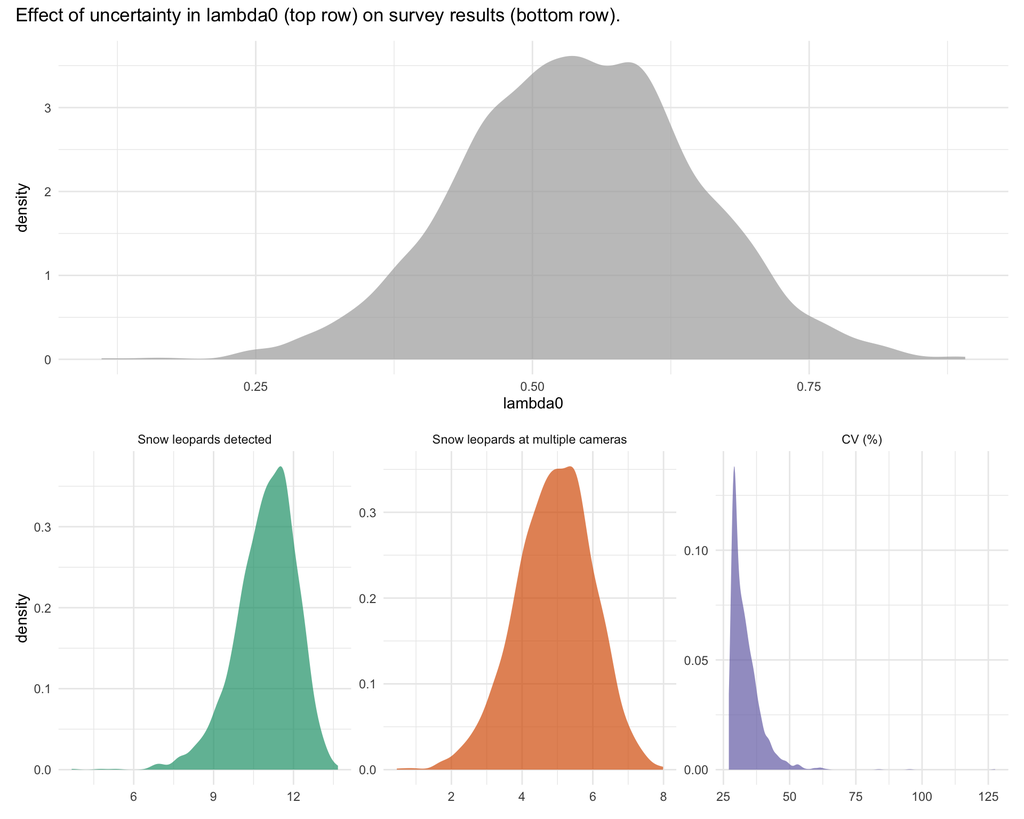

```r
# Convert data to long format suitable for plotting
secr.params.uncertain.plotdat <- melt(secr.params.uncertain, measure.vars=c("En", "Er", "Em", "En2", "CV"))

# Subset down to the three metrics of main interest
secr.params.uncertain.plotdat <- secr.params.uncertain.plotdat[secr.params.uncertain.plotdat$variable %in% c("En", "En2", "CV"), ]

# Give the metrics clearer names
secr.params.uncertain.plotdat$variable <- factor(secr.params.uncertain.plotdat$variable)
levels(secr.params.uncertain.plotdat$variable) <- c("Snow leopards detected", "Snow leopards at multiple cameras", "CV (%)")

# Plot a multi-planel figure showing potential uncertainty in lambda0 and the effect on survey results
p.top1 <- ggplot(data=secr.params.uncertain.plotdat[secr.params.uncertain.plotdat$uncertain.params=="lambda0", ], aes(x=lambda0)) +
  geom_density(fill="darkgrey", colour=NA, alpha=0.7) +
  theme_minimal() +
  theme(legend.position="none")

p.bottom1 <- ggplot(data=secr.params.uncertain.plotdat[secr.params.uncertain.plotdat$uncertain.params=="lambda0", ], aes(x=value, fill=variable)) +
  geom_density(alpha=0.7, colour=NA) +
  scale_fill_brewer(palette="Dark2") +
  facet_wrap(~variable, scales="free") +
  theme_minimal() +
  theme(legend.position="none", axis.title.x=element_blank())

p.top1 / p.bottom1 + plot_annotation(title="Effect of uncertainty in lambda0 (top row) on survey results (bottom row).")
```

Plot the marginal effect of uncertainty about sigma.

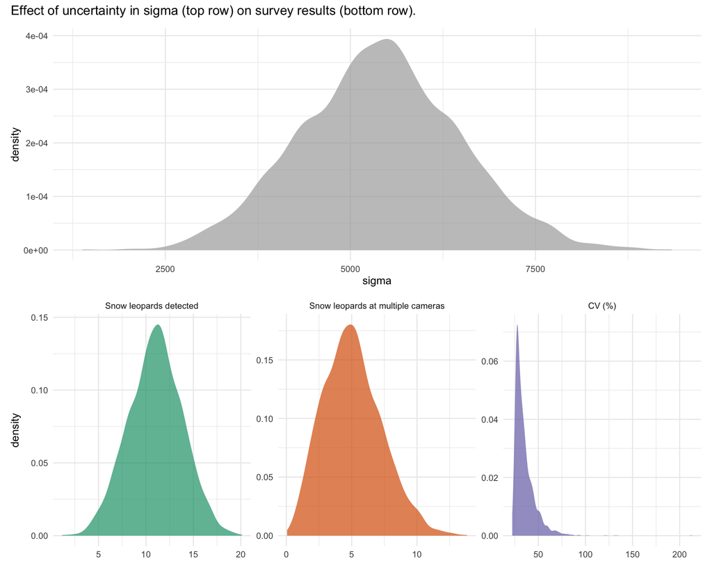

```r
# Plot a multi-planel figure showing potential uncertainty in sigma and the effect on survey results
p.top2 <- ggplot(data=secr.params.uncertain.plotdat[secr.params.uncertain.plotdat$uncertain.params=="sigma", ], aes(x=sigma)) +
  geom_density(fill="darkgrey", colour=NA, alpha=0.7) +
  theme_minimal() +
  theme(legend.position="none")

p.bottom2 <- ggplot(data=secr.params.uncertain.plotdat[secr.params.uncertain.plotdat$uncertain.params=="sigma", ], aes(x=value, fill=variable)) +
  geom_density(alpha=0.7, colour=NA) +
  scale_fill_brewer(palette="Dark2") +
  facet_wrap(~variable, scales="free") +
  theme_minimal() +
  theme(legend.position="none", axis.title.x=element_blank())

p.top2 / p.bottom2 + plot_annotation(title="Effect of uncertainty in sigma (top row) on survey results (bottom row).")
```

Plot the marginal effect of uncertainty about density.

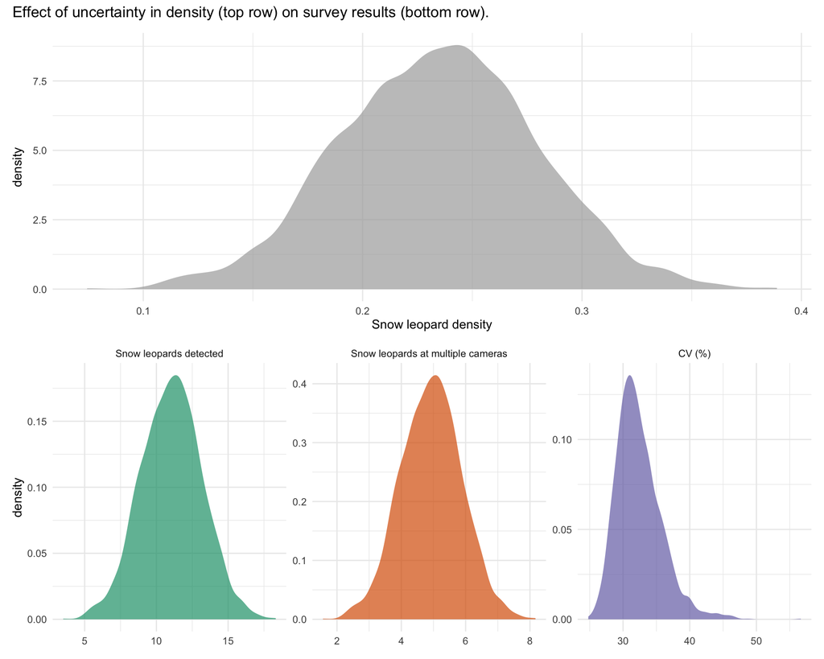

```r
# Plot a multi-planel figure showing potential uncertainty in density and the effect on survey results
p.top3 <- ggplot(data=secr.params.uncertain.plotdat[secr.params.uncertain.plotdat$uncertain.params=="density", ], aes(x=density)) +
  geom_density(fill="darkgrey", colour=NA, alpha=0.7) +
  theme_minimal() +
  labs(x="Snow leopard density") +
  theme(legend.position="none")

p.bottom3 <- ggplot(data=secr.params.uncertain.plotdat[secr.params.uncertain.plotdat$uncertain.params=="density", ], aes(x=value, fill=variable)) +
  geom_density(alpha=0.7, colour=NA) +
  scale_fill_brewer(palette="Dark2") +
  facet_wrap(~variable, scales="free") +
  theme_minimal() +
  theme(legend.position="none", axis.title.x=element_blank())

p.top3 / p.bottom3 + plot_annotation(title="Effect of uncertainty in density (top row) on survey results (bottom row).")
```

Plot the effect of uncertainty about all three SECR parameters, assuming naively that there’s no correlation among the three parameters.

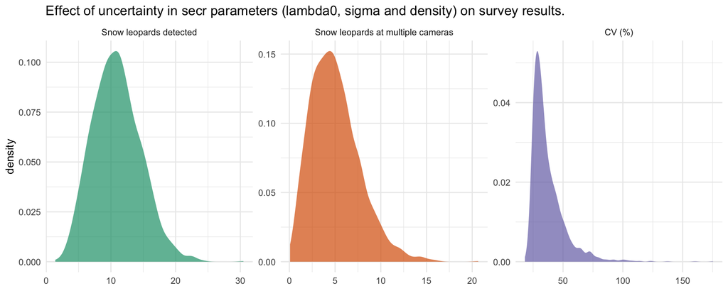

```r
# Plot a multi-planel figure showing the effect of uncertainty about snow leopard density on survey results
ggplot(data=secr.params.uncertain.plotdat[secr.params.uncertain.plotdat$uncertain.params=="all", ], aes(x=value, fill=variable)) +
  geom_density(alpha=0.7, colour=NA) +
  scale_fill_brewer(palette="Dark2") +
  facet_wrap(~variable, scales="free") +
  theme_minimal() +
  labs(title="Effect of uncertainty in secr parameters (lambda0, sigma and density) on survey results.") +
  theme(legend.position="none", axis.title.x=element_blank())
```

Across these plots, we can see that uncertainty about *sigma* has the most important effect. If *sigma* is very small, for example < 3 km, then we’ll get few snow leopards on multiple cameras, meaning that *sigma* will be poorly estimated. This might cause bias and loss of precision in the density estimate. There is also a very small chance that the survey fails altogether, if no snow leopards are recorded on multiple cameras.

### 5.4. Spacing between camera traps

Camera spacing is critical in SECR surveys, since we need spatial recaptures at varying distances from an animal’s home-range centre in order to estimate the detection function. This is especially critical for estimation of the movement scale parameter, *sigma*.

We can plot the distribution of inter-camera distances to check we have cameras at a range of distances from each other.

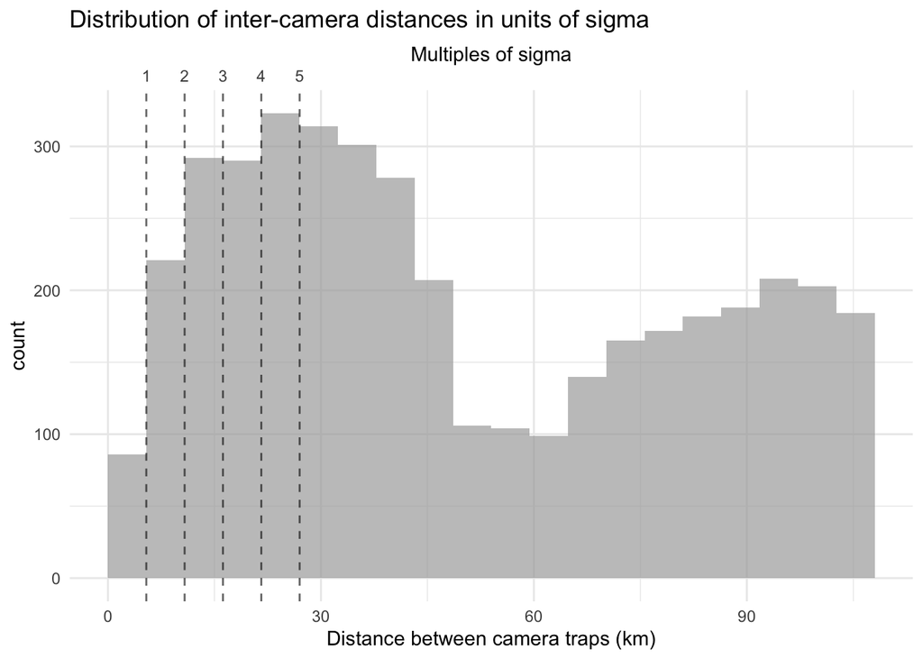

```r
# Calculate distances among cameras
dists <- st_distance(cameras.both.sf)

# Extract just the lower triange of this matrix
dists <- dists[lower.tri(dists)]

# Plot a histogram of the distances
ggplot(data=data.frame(dists), aes(x=as.numeric(dists) / 1000)) +
  geom_histogram(fill="darkgrey", colour=NA, alpha=0.7, breaks=0:20*expected.sigma/1000) +
  theme_minimal() +
  labs(x="Distance between camera traps (km)") +
  #scale_x_continuous(breaks=(expected.sigma*c(1:5))/1000, labels=(expected.sigma*c(1:5))/1000)
  scale_x_continuous(sec.axis=sec_axis(~. / (expected.sigma/1000), name="Multiples of sigma", breaks=c(1, 2, 3, 4, 5))) +
  geom_vline(xintercept = 1:5*expected.sigma/1000, linetype=2, alpha=0.6) +
  labs(title="Distribution of inter-camera distances in units of sigma")
```

The survey has a relatively large number of camera trap pairs in the range crucial range of 2-4 x sigma. This gives the survey the best possible chance of recording snow leopards at a range of distances from the home-range centres.

### 5.5. Covariate coverage

A good survey of the conservancies will cover the full range of snow leopard habitats they contain. One key covariate that drives snow leopard density is ruggedness. We can assess what range of ruggedness values is covered by the proposed survey design.

We extract the ruggedness values both at the exact camera locations, but also within a broader radius around cameras (within 4 km, following Durbach, 2022, ‘Evaluation of proposed final design for camera trap survey of snow leopards in Bhutan’). We do this because, for SECR modelling, covariate coverage must be adequate not just at camera locations, but also across the much larger region where detected animals may have their home-range centres.

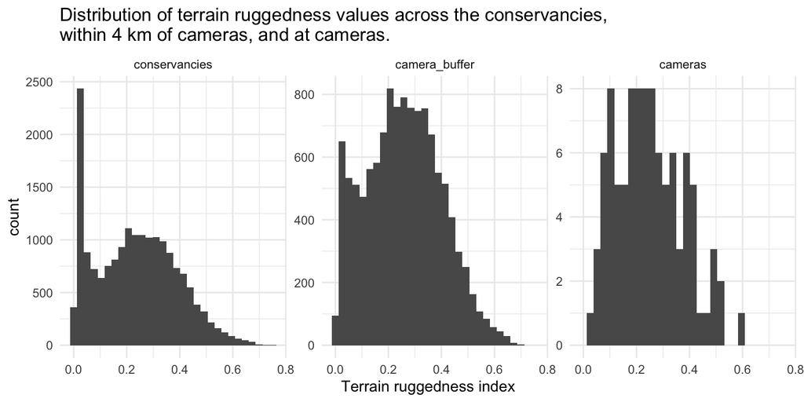

```r
# Extract the range of ruggedness values
rugged.conservancy <- values(rugged.low)

# Extract the values at camera trap locations
rugged.cameras <- extract(rugged.low, cameras.both.sf)

# Extract the values within 4 km of camera traps
cameras.both.sf.buffer <- st_union(st_buffer(cameras.both.sf, 4000))
rugged.cameras.buffer <- mask(rugged.low, st_as_sf(cameras.both.sf.buffer))
rugged.cameras.buffer <- values(rugged.cameras.buffer)

# Plot the distributions
ruggedness.plotdat <- rbind(
  data.frame(data="conservancies", ruggedness=rugged.conservancy),
  data.frame(data="cameras", ruggedness=rugged.cameras),
  data.frame(data="camera_buffer", ruggedness=rugged.cameras.buffer)
)
ruggedness.plotdat$data <- factor(ruggedness.plotdat$data, levels=c("conservancies", "camera_buffer", "cameras"))
ggplot(data=ruggedness.plotdat, aes(x=ruggedness)) +
  geom_histogram() +
  facet_wrap(~data, scales="free_y") +
  labs(title="Distribution of terrain ruggedness values across the conservancies, \nwithin 4 km of cameras, and at cameras.", x="Terrain ruggedness index") +
  theme_minimal()
```

The area within the 4 km buffers around camera traps resembles the conditions across the conservancies in terms of ruggedness, although with a less pronounced peak at low ruggedness because the large flat area in Zhanaidar was clipped out.

For the exact camera locations, the range of ruggedness values that are sampled appears to cover the range that exists across the conservancies, but the distribution is a bit different.

Of course, the final camera trap locations in the field will be different to these planned locations, so this is indicative only.

## 6. Evaluation of the separate survey design for Zhanaidar

Next we’ll evaluate the smaller of the two surveys - Zhanaidar - to get an idea of how just one of the surveys on its own will perform for surveying snow leopards.

### 6.1. Expected number of individuals & recaptures

```r
# Calculate metrics for generated survey design
expected.data.zh <- Enrm(traps = proposed.design.zh.loss10$optimaltraps, mask = design.mask.zh, detectpar = secr.params, D = expected.density / 10000, noccasions = 1, detectfn = "HHN")

# Convert to a data frame
expected.data.zh <- data.frame(Metric=c("Expected number of snow leopards", "Expected recaptures", "Expected movement recaptures"), Value=as.numeric(expected.data.zh))

# Add the number of snow leopards detected at > 1 camera
expected.data.zh <- rbind(expected.data.zh, data.frame(Metric="Expected snow leopards detected at multiple cameras", Value=En2(traps = proposed.design.zh.loss10$optimaltraps, mask = design.mask.zh, detectpar = secr.params, D = expected.density / 10000, noccasions = 1, detectfn = "HHN")["En2"]))

# Output a table
kable(expected.data.zh, check.names=F, row.names=F, caption="Expected data produced from the Zhanaidar survey design.", digits=2) %>%
  kable_styling(bootstrap_options = c("striped", "hover"), full_width=F)
```

Expected data produced from the Zhanaidar survey design.

| Metric | Value |
| --- | --- |
| Expected number of snow leopards | 4.39 |
| Expected recaptures | 3.98 |
| Expected movement recaptures | 3.29 |
| Expected snow leopards detected at multiple cameras | 1.95 |

We can see that the survey is likely to detect only 4 snow leopards, which will not be enough to estimate population density/abundance in the area.

### 6.2. Expected coefficient of variation (CV)

```r
# Calculate expected coefficient of variation (CV)
expected.cv.zh <- 100 * minnrRSE(traps = proposed.design.zh.loss10$optimaltraps, mask = design.mask.zh, detectpar = secr.params, D = expected.density / 10000, noccasions = 1, detectfn = "HHN")

# Output a table
kable(data.frame(Metric="Expected coefficient of variation (CV)", Value=paste0(round(expected.cv.zh, 2), " %")), check.names=F, row.names=F, caption="Expected CV produced from the Zhanaidar survey design.", digits=2) %>%
  kable_styling(bootstrap_options = c("striped", "hover"), full_width=F)
```

Expected CV produced from the Zhanaidar survey design.

| Metric | Value |
| --- | --- |
| Expected coefficient of variation (CV) | 50.15 % |

The CV of the estimate is also likely to be very large.

### 6.3. Incorporating uncertainty about the SECR parameters

```r
secr.params.uncertain.zh <- adply(secr.params.uncertain, 1, .fun=param.uncertainty, design=proposed.design.zh.loss10$optimaltraps)
```

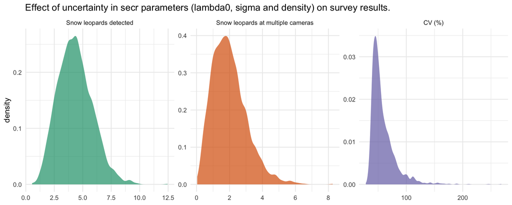

```r
# Convert data to long format suitable for plotting
secr.params.uncertain.zh.plotdat <- melt(secr.params.uncertain.zh, measure.vars=c("En", "Er", "Em", "En2", "CV"))

# Subset down to the three metrics of main interest
secr.params.uncertain.zh.plotdat <- secr.params.uncertain.zh.plotdat[secr.params.uncertain.zh.plotdat$variable %in% c("En", "En2", "CV"), ]

# Give the metrics clearer names
secr.params.uncertain.zh.plotdat$variable <- factor(secr.params.uncertain.zh.plotdat$variable)
levels(secr.params.uncertain.zh.plotdat$variable) <- c("Snow leopards detected", "Snow leopards at multiple cameras", "CV (%)")

# Plot a multi-planel figure showing the effect of uncertainty about snow leopard density on survey results
ggplot(data=secr.params.uncertain.zh.plotdat[secr.params.uncertain.zh.plotdat$uncertain.params=="all", ], aes(x=value, fill=variable)) +
  geom_density(alpha=0.7, colour=NA) +
  scale_fill_brewer(palette="Dark2") +
  facet_wrap(~variable, scales="free") +
  theme_minimal() +
  labs(title="Effect of uncertainty in secr parameters (lambda0, sigma and density) on survey results.") +
  theme(legend.position="none", axis.title.x=element_blank())
```

Accounting for potential uncertainty in the SECR parameters, we can expect to detect around 2-7 snow leopards, with 1-3 detected at multiple cameras.

## 7. Export the designs

Finally we export the designs, without the 10% loss factor on the camera locations. If all of 100 of the camera traps are successfully placed in the field, then the survey results could be marginally better than assessed above.

Note: field teams should be instructed to place cameras inside the selected grid cells, targeting areas likely to be used by snow leopards (e.g. saddles, overhanding rocks etc.). However, cameras in neighbouring grid cells should ideally be placed > 1 km apart. Cameras placed close together provide duplicate information about snow leopard density and movement, which is an inefficient use of field resources.

Export the combined design:

```r
# Extract the final camera locations
cameras.sf.final <- st_as_sf(proposed.design.both$optimaltraps, coords=c("x", "y"), crs=study.crs)

# Add an ID field
cameras.sf.final$camera_ID <- paste0("CT", 1:nrow(cameras.sf.final))

# Create a 2 km grid with the cameras at the grid centres; camera traps will be placed by field teams at suitable locations within these grid cells
final.grid <- (st_bbox(cameras.sf.final) + minimum.spacing/2*c(-1,-1,1,1)) %>%
  st_make_grid(cellsize=rep(minimum.spacing, 2)) %>% st_sf()

# Subset it to the grid cells touching the conservancies
final.grid <- final.grid[survey.area.vect, op=st_intersects]

# Subset to the cells that were selected for camera traps
final.grid.selected <- final.grid[cameras.sf.final, op=st_intersects]

# Plot it
leaflet() %>%
  addProviderTiles("Esri.WorldImagery") %>%
  addPolylines(data=st_transform(conservancy, "EPSG:4326"), color="black", opacity=0.8, weight=2) %>%
  addPolylines(data=st_transform(final.grid, "EPSG:4326"), color="grey", opacity=0.8, weight=2) %>%
  addPolylines(data=st_transform(final.grid.selected, "EPSG:4326"), color="red", opacity=0.8, weight=2) %>%
  addCircleMarkers(data=st_transform(cameras.sf.final, "EPSG:4326"), stroke=T, weight=1.2, fillOpacity = 0.8, color="black", fillColor="red", radius=4, popup=cameras.sf.final$camera_ID)
```

[interactive chart not shown]

```r
# Export the camera points and grid to geopackages
#write_sf(cameras.sf.final, "GIS/Kyrgyzstan/UNDP Pamir-Alay/Zhanaidar-Bek Tosot cam trap/camera_points_conservancies.gpkg")
#write_sf(final.grid.selected, "GIS/Kyrgyzstan/UNDP Pamir-Alay/Zhanaidar-Bek Tosot cam trap/camera_grid_conservancies.gpkg")

# Also export the survey area
#write_sf(survey.area.vect, "GIS/Kyrgyzstan/UNDP Pamir-Alay/Zhanaidar-Bek Tosot cam trap/survey_area_conservancies.gpkg")
```

And export the two separate designs for each conservancy:

```r
# Extract the final camera locations for each of the conservancies separately
cameras.sf.final.zh <- st_as_sf(proposed.design.zh$optimaltraps, coords=c("x", "y"), crs=study.crs)
cameras.sf.final.bt <- st_as_sf(proposed.design.bt$optimaltraps, coords=c("x", "y"), crs=study.crs)

# Add an ID field
cameras.sf.final.zh$camera_ID <- paste0("ZH", 1:nrow(cameras.sf.final.zh))
cameras.sf.final.bt$camera_ID <- paste0("BT", 1:nrow(cameras.sf.final.bt))

# Create 2 km grids with the cameras at the grid centres
final.grid.zh <- (st_bbox(cameras.sf.final.zh) + minimum.spacing/2*c(-1,-1,1,1)) %>%
  st_make_grid(cellsize=rep(minimum.spacing, 2)) %>% st_sf()
final.grid.bt <- (st_bbox(cameras.sf.final.bt) + minimum.spacing/2*c(-1,-1,1,1)) %>%
  st_make_grid(cellsize=rep(minimum.spacing, 2)) %>% st_sf()

# Subset to the grid cells touching the conservancies
final.grid.zh <- final.grid.zh[survey.area.vect, op=st_intersects]
final.grid.bt <- final.grid.bt[survey.area.vect, op=st_intersects]

# Subset to the cells that were selected for camera traps
final.grid.selected.zh <- final.grid.zh[cameras.sf.final.zh, op=st_intersects]
final.grid.selected.bt <- final.grid.bt[cameras.sf.final.bt, op=st_intersects]

# Plot it
leaflet() %>%
  addProviderTiles("Esri.WorldImagery") %>%
  addPolylines(data=st_transform(conservancy, "EPSG:4326"), color="black", opacity=0.8, weight=2) %>%
  addPolylines(data=st_transform(final.grid.zh, "EPSG:4326"), color="grey", opacity=0.8, weight=2) %>%
  addPolylines(data=st_transform(final.grid.bt, "EPSG:4326"), color="grey", opacity=0.8, weight=2) %>%
  addPolylines(data=st_transform(final.grid.selected.zh, "EPSG:4326"), color="red", opacity=0.8, weight=2) %>%
  addPolylines(data=st_transform(final.grid.selected.bt, "EPSG:4326"), color="red", opacity=0.8, weight=2) %>%
  addCircleMarkers(data=st_transform(cameras.sf.final.zh, "EPSG:4326"), stroke=T, weight=1.2, fillOpacity = 0.8, color="black", fillColor="red", radius=4, popup=cameras.sf.final$camera_ID) %>%
  addCircleMarkers(data=st_transform(cameras.sf.final.bt, "EPSG:4326"), stroke=T, weight=1.2, fillOpacity = 0.8, color="black", fillColor="red", radius=4, popup=cameras.sf.final$camera_ID)
```

[interactive chart not shown]

```r
# Export the camera points and grid to geopackages
#write_sf(cameras.sf.final.zh, "GIS/Kyrgyzstan/UNDP Pamir-Alay/Zhanaidar-Bek Tosot cam trap/camera_points_zhanaidar.gpkg")
#write_sf(cameras.sf.final.bt, "GIS/Kyrgyzstan/UNDP Pamir-Alay/Zhanaidar-Bek Tosot cam trap/camera_points_bektosot.gpkg")
#write_sf(final.grid.selected.zh, "GIS/Kyrgyzstan/UNDP Pamir-Alay/Zhanaidar-Bek Tosot cam trap/camera_grid_zhanaidar.gpkg")
#write_sf(final.grid.selected.bt, "GIS/Kyrgyzstan/UNDP Pamir-Alay/Zhanaidar-Bek Tosot cam trap/camera_grid_bektosot.gpkg")
```